# Playing Around with Fitness Functions

Imports

Play around with different fitness functions

```r
#x = seq(-1,1, by=0.05)
#y = oneTraitFitFunc(x)

#df <- data.frame(x=x, y=y)
#ggplot(data=df, aes(x=x, y=y)) +
#    geom_line() +
#    geom_point() +
#    labs(x = "Trait Value", y = "Fitness")

fitness_x = seq(-1,1, by=0.05)
fitness_y = seq(-1,1, by=0.05)
fitness_z = outer(fitness_x,fitness_y,calculateFitnessTwoTrait)


p <- plot_ly(x=fitness_x,
        y=fitness_y,
        z=fitness_z,
        type='surface',
        colors = "PuBuGn",
        opacity=1) %>%
  layout(scene = list(xaxis = list(title = "Trait A"),
                      yaxis = list(title = "Trait B"),
                      zaxis = list(title = "Fitness"),
                      aspectmode='cube'))

save_dir <- file.path(output_dir, "FitnessFunctions")
if (!dir.exists(save_dir)) dir.create(save_dir)
save_dir <- file.path(save_dir, format(Sys.time(), "%F_%H_%M_%S"))
if (!dir.exists(save_dir)) dir.create(save_dir)
fname <- file.path(save_dir, "fitness_function.html")
htmlwidgets::saveWidget(as_widget(p), fname)
# Valid arguments:
# colors = "PuBuGn"
# colors = colorRampPalette(c("blue", "orange"))(15)
# colors = magma(50, alpha = 1, begin = 0, end = 1, direction = 1) (viridis, plasma, magma, inferno)
```

Show that all individuals converge to a fitness maximum

```r
start_trait_val <- c(-3,-2,-1,1,2,3)
n.sims <- length(start_trait_val)
n.popSize <- 50
n.segSites <- 50
n.gens <- 50
n.chr <- 10

df <- data.frame(gen=rep(1:n.gens, times=n.sims),
                 fitness=numeric(n.gens*n.sims),
                 initialVal = numeric(n.gens*n.sims),
                 traitVal=numeric(n.gens*n.sims))

for (s in 1:n.sims) {
  initVal <- start_trait_val[s]
  founders = quickHaplo(
     nInd=n.popSize,
     nChr=n.chr,
     segSites=n.segSites
  )
  SP <- SimParam$new(founders)
  SP$addTraitA(
    mean=initVal,
    var=abs(initVal/10),
    nQtlPerChr=n.qtlPerChr
  )
  SP$setVarE(h2=n.h2)
  pop <- newPop(founders, simParam=SP)

  for(gen in 1:n.gens) {
    idx = (s-1)*n.gens + gen
    df$fitness[idx] <- mean(oneTraitFitFunc(pheno(pop)))
    df$traitVal[idx] <- meanP(pop)
    df$initialVal[idx] <- initVal
    pop <- selectCross(pop=pop, trait=oneTraitFitFunc, nInd=n.popSize/2, nCrosses=n.popSize)
  }
}

df$initialVal = as.character(df$initialVal)
g <- ggplot(data=df, aes(x=gen, y=traitVal)) +
  geom_line(aes(color = initialVal)) +
  labs(x = "Generation", y = "Trait Value")

save_dir <- file.path(output_dir, "ConvergingFitness")
if (!dir.exists(save_dir)) dir.create(save_dir)
save_dir <- file.path(save_dir, format(Sys.time(), "%F_%H_%M_%S"))
if (!dir.exists(save_dir)) dir.create(save_dir)
write.table(getParams(), file.path(save_dir, "params.txt"), col.names=FALSE, quote=FALSE, sep=":\t")

ggplot2::ggsave(filename = "converging_fitness.pdf",
                path=save_dir,
                device = "pdf")
```

Plot Trait Value against Fitness

```r
n.gens <- 50
n.segSites <- 1000

founders = quickHaplo(
   nInd=n.popSize,
   nChr=n.chr,
   segSites=n.segSites
)
SP <- SimParam$new(founders)
SP$addTraitA(
  nQtlPerChr=n.qtlPerChr,
  mean=n.initTraitVal,
  var=n.rate,
)
SP$setVarE(h2=n.h2)
pop <- newPop(founders, simParam=SP)

fit_df <- data.frame(gen=1:n.gens,
                 fitness=numeric(n.gens),
                 traitVal=numeric(n.gens))
for(gen in 1:n.gens) {
  fit_df$fitness[gen] <- mean(oneTraitFitFunc(pheno(pop)))
  fit_df$traitVal[gen] <- meanP(pop)
  pop <- selectCross(pop=pop, trait=oneTraitFitFunc, nInd=n.popSize/2, nCrosses=n.popSize)
}

save_dir <- file.path(output_dir, "TraitValVsFitness")
if (!dir.exists(save_dir)) dir.create(save_dir)
save_dir <- file.path(save_dir, format(Sys.time(), "%F_%H_%M_%S"))
if (!dir.exists(save_dir)) dir.create(save_dir)
write.table(getParams(), file.path(save_dir, "params.txt"), col.names=FALSE, quote=FALSE, sep=":\t")


fname <- file.path(save_dir, "traitvalue_vs_fitness.pdf")
pdf(fname)
par(mar = c(5, 5, 3, 5) + 0.3)
plot(fit_df$gen, fit_df$traitVal, type="l", lwd = "3", col=2, xlab = "Generation", ylab = "Trait Value")
par(new = TRUE)
plot(fit_df$gen, fit_df$fitness, type="l", lwd = "3", col = 3, axes = FALSE, xlab = "", ylab = "")
```

```r
axis(side = 4, at = pretty(range(fit_df$fitness)))
mtext("Fitness", side = 4, line = 3)
par(xpd=TRUE)
legend("right",
  c("Trait Value", "Fitness"),
       lty = 1,
       lwd = 3,
       col = 2:3)
dev.off()
```

Out of alleles left in the population, how many of them would increase fitness? TODO: Next: how does this change with size of allele? Look at editGenomeTopQtl() Next: how does size of ‘fitness delta’ change over generations? Simualate mutations for a single individual to figure out P(allelic substitution is favorable) - should reflect FKO P(mutation gets fixed) - show that this matches Kimura Compare adaptive walks for DH/inbred population where there are new mutations VS population w/standing genetic variation

```r
n.popSize = 200
n.segSites = 100
n.gens <- 10

founders = runMacs(
   nInd=n.popSize,
   nChr=n.chr,
   segSites=n.segSites
)
SP <- SimParam$new(founders)
SP$addTraitA(mean=n.initTraitVal, var=n.rate, nQtlPerChr=n.qtlPerChr, gamma = TRUE, shape = n.shape)
SP$addTraitA(mean=n.initTraitVal, var=n.rate, nQtlPerChr=n.qtlPerChr, gamma = TRUE, shape = n.shape)
SP$setVarE(h2=c(n.h2,n.h2))
pop <- newPop(founders, simParam = SP)

fitFunc <- twoTraitFitFunc

cols = colnames(pullSegSiteGeno(pop))
df <- data.frame(gen=rep(1:n.gens),
                 fitness=numeric(n.gens),
                 traitVal1=numeric(n.gens),
                 traitVal2=numeric(n.gens),
                 percFitInc=numeric(n.gens),
                 segAlleles=numeric(n.gens))

for (gen in 1:n.gens) {
  print(gen)
  mean(fitFunc(gv(pop)))
  df$fitness[gen] <- mean(fitFunc(gv(pop)))
  df$traitVal1[gen] <- meanG(pop)[1]
  df$traitVal2[gen] <- meanG(pop)[2]
  num_het_loci = 0
  num_inc = 0
  geno <- pullSegSiteGeno(pop)
  cols <- colnames(geno)
  nLoci <- ncol(geno)
  for (l in 1:nLoci) {
    id <- cols[l]
    strs = unlist(strsplit(cols[l], "_"))
    chr = strtoi(strs[1])
    site = strtoi(strs[2])
    locus = geno[,l]
    e <- getEffectSize(locus, id, fitFunc, pop, "MethodB")
    if (!is.na(e)) {
      num_het_loci <- num_het_loci + 1
      if (e > 0) {
        num_inc <- num_inc + 1
      }
    }
  }

  if (num_het_loci == 0) {
    perc <- 0
  } else {
    perc <- (num_inc / num_het_loci)
  }
  df$segAlleles[gen] <- num_het_loci
  df$percFitInc[gen] <- perc
  pop <- selectCross(pop=pop, trait=fitFunc, nInd=nInd(pop)*n.selProp, nCrosses=nInd(pop))
}
```

```
[1] 1
[1] 2
[1] 3
[1] 4
[1] 5
[1] 6
[1] 7
[1] 8
[1] 9
[1] 10
```

```r
save_dir <- file.path(output_dir, "BeneficialAlleles")
if (!dir.exists(save_dir)) dir.create(save_dir)
save_dir <- file.path(save_dir, format(Sys.time(), "%F_%H_%M_%S"))
if (!dir.exists(save_dir)) dir.create(save_dir)
write.table(getParams(), file.path(save_dir, "params.txt"), col.names=FALSE, quote=FALSE, sep=":\t")

fname <- file.path(save_dir, "beneficialalleles.pdf")
pdf(fname)

par(mar = c(5, 5, 3, 5) + 0.3)
plot(df$gen, df$fitness, type="l", lwd = "3", col=2, xlab = "Generation", ylab = "Fitness")
par(new = TRUE)
plot(df$gen, df$percFitInc, type="l", lwd = "3", col = 3, axes = FALSE, xlab = "", ylab = "")
```

```r
axis(side = 4, at = pretty(range(df$percFitInc)))
mtext("% of Segregating alleles that are Beneficial", side = 4, line = 3)
par(xpd=TRUE)
legend("right",
  c("Trait Value", "% Alleles"),
       lty = 1,
       lwd = 3,
       col = 2:3)
dev.off()
```

```r
#ggplot(data=df, aes(x=gen, y=segAlleles)) +
#  geom_line() +
#  labs(x = "Generation", y = "Num Segregating Alleles")
```

Simulate several adaptive walks with different population sizes

```r
n.gens = 50
n.popSizes = c(100,500,1000)
n.segSites = 500

fig <- plot_ly()
fit_df <- data.frame(gen=1:n.gens,
                   fitness=numeric(n.gens),
                   traitValA=numeric(n.gens),
                   traitValB=numeric(n.gens))
for (p in c(1:length(n.popSizes))) {
  n.popSize = n.popSizes[p]
  print(n.popSize)
  founders = runMacs(
     nInd=n.popSize,
     nChr=n.chr,
     segSites=n.segSites
  )
  SP <- SimParam$new(founders)
  SP$addTraitA(mean=c(n.initTraitVal,n.initTraitVal), var=c(n.shape,n.shape), nQtlPerChr=n.qtlPerChr)

  SP$setVarE(h2=c(n.h2,n.h2))
  foundingPop <- newPop(founders, simParam = SP)

  pop <- foundingPop

  for(gen in 1:n.gens) {
    fit_df$fitness[gen] <- mean(twoTraitFitFunc(pheno(pop)))
    fit_df$traitValA[gen] <- meanP(pop)[1]
    fit_df$traitValB[gen] <- meanP(pop)[2]
    pop <- selectCross(pop, trait=twoTraitFitFunc, nInd=n.popSize*(n.selProp), nCrosses=n.popSize)
  }

  fig <- add_trace(
    fig,
    fit_df,
    name = n.popSize,
    x = fit_df$traitValA,
    y = fit_df$traitValB,
    z = fit_df$fitness,
    type = 'scatter3d',
    mode = 'lines',
    opacity = 1,
    color = p,
    line = list(width = 10)
  )

}
```

```
[1] 100
[1] 500
[1] 1000
```

```r
fig <- fig %>%
  layout(legend=list(title=list(text='Population Size')),
         scene = list(xaxis = list(title = "Trait A"),
                      yaxis = list(title = "Trait B"),
                      zaxis = list(title = "w"),
                      aspectmode='cube')) %>% hide_colorbar()


save_dir <- file.path(output_dir, "DifferentPopulationSizes")
if (!dir.exists(save_dir)) dir.create(save_dir)
save_dir <- file.path(save_dir, format(Sys.time(), "%F_%H_%M_%S"))
if (!dir.exists(save_dir)) dir.create(save_dir)
write.table(getParams(), file.path(save_dir, "params.txt"), col.names=FALSE, quote=FALSE, sep=":\t")

fname <- file.path(save_dir, paste0("populationSizes_", n.popSizes[1], ",", n.popSizes[2], ",", n.popSizes[3], ".html"))
htmlwidgets::saveWidget(as_widget(fig), fname)
```

Overlay an adaptive walk over a fitness landscape

```r
set.seed(123)

n.gens = 50
n.popSize = 200
n.segSites = 50
plotType="CONTOUR"

fig <- plot_ly()
fit_df <- data.frame(gen=1:n.gens,
                   fitness=numeric(n.gens),
                   traitValA=numeric(n.gens),
                   traitValB=numeric(n.gens))
founders = runMacs(
   nInd=n.popSize,
   nChr=n.chr,
   segSites=n.segSites
)
SP <- SimParam$new(founders)
SP$addTraitA(mean=c(runif(1,n.initTraitVal*-1,n.initTraitVal),runif(1,n.initTraitVal*-1,n.initTraitVal)), var=c(n.rate,n.rate), nQtlPerChr=n.qtlPerChr)

SP$setVarE(h2=c(n.h2,n.h2))
foundingPop <- newPop(founders, simParam = SP)

pop <- foundingPop

for(gen in 1:n.gens) {
  fit_df$fitness[gen] <- mean(twoTraitFitFunc(gv(pop)))
  fit_df$traitValA[gen] <- meanG(pop)[1]
  fit_df$traitValB[gen] <- meanG(pop)[2]
  pop <- selectCross(pop, trait=twoTraitFitFunc, nInd=n.popSize*n.selProp, nCrosses=n.popSize)
}

p <- overlayWalkOnLandscape(fit_df, type=plotType, calculateFitnessTwoTrait)

save_dir <- file.path(output_dir, "OverlayAdaptiveWalk")
if (!dir.exists(save_dir)) dir.create(save_dir)
save_dir <- file.path(save_dir, format(Sys.time(), "%F_%H_%M_%S"))
if (!dir.exists(save_dir)) dir.create(save_dir)
fname <- file.path(save_dir, paste0("adaptivewalk_", plotType, ".html"))
htmlwidgets::saveWidget(as_widget(p), fname)
```

```r
n.popSize <- 500
n.subPopSize <- 100
n.segSites <- 100

source("CreateFounderPop.R")

fit_df <- data.frame(gen=1:n.burnInGens,
                   fitness=numeric(n.burnInGens),
                   traitValA=numeric(n.burnInGens),
                   traitValB=numeric(n.burnInGens))

pop <- foundingPop

# BURN-IN
for (gen in 1:n.burnInGens) {
  fit_df$fitness[gen] <- mean(twoTraitFitFunc(pheno(pop)))
  fit_df$traitValA[gen] <- meanP(pop)[1]
  fit_df$traitValB[gen] <- meanP(pop)[2]
  pop <- selectCross(pop, trait=twoTraitFitFunc, nInd=n.popSize*n.burnInSelProp, nCrosses=n.popSize)
}


fig <- plot_ly()

fig <- add_trace(
  fig,
  fit_df,
  name = "Burn In",
  x = fit_df$traitValA,
  y = fit_df$traitValB,
  z = fit_df$fitness,
  type = 'scatter3d',
  mode = 'lines',
  opacity = 1,
  color = 'yellow',
  line = list(width = 5)
)

n.gens <- 120
subPop_df <- data.frame(gen=1:n.gens,
                   fitness=numeric(n.gens),
                   traitValA=numeric(n.gens),
                   traitValB=numeric(n.gens))

n.sims <- 2
# figure out how to do this dynamically
eff_size_df <- data.frame(orderFixed=c(),
                          effectSize=c())


for (s in 1:n.sims) {
  print(s)
  # Figure out a better way to select randomly? or by traitA, traitB?
  subPop <- selectInd(pop, use="rand", nInd=n.subPopSize)
  idx <- 1
  inc <- FALSE

  for (gen in 1:n.gens) {
    subPop_df$fitness[gen] <- mean(twoTraitFitFunc(pheno(subPop)))
    subPop_df$traitValA[gen] <- meanP(subPop)[1]
    subPop_df$traitValB[gen] <- meanP(subPop)[2]
    prevPop <- subPop
    subPop <- selectCross(subPop, trait=twoTraitFitFunc, nInd=nInd(subPop)*n.selProp, nCrosses=nInd(subPop))
    prevGeno <- pullQtlGeno(prevPop,1)
    if (prevPop@nTraits > 1) {
      for (t in 2:prevPop@nTraits) {
        prevGeno <- cbind(prevGeno, pullQtlGeno(prevPop, trait=t))
      }
    }
    prevGeno <- prevGeno[, !duplicated(colnames(prevGeno))]
    newGeno <- pullQtlGeno(subPop,1)
    if (subPop@nTraits > 1) {
      for (t in 2:subPop@nTraits) {
        newGeno <- cbind(newGeno, pullQtlGeno(subPop, trait=t))
      }
    }
    newGeno <- newGeno[, !duplicated(colnames(newGeno))]
    cols <- colnames(newGeno)
    n.loci <- length(cols)
    for (l in 1:n.loci) {
      id <- cols[l]
      #strs = unlist(strsplit(id, "_"))
      #chr = strtoi(strs[1])
      #site = strtoi(strs[2])
      prevLocus = prevGeno[,l]
      newLocus = newGeno[,l]
      if (hetLocus(prevLocus) && !hetLocus(newLocus)) {
        effSize <- getEffectSize(prevLocus,
                                  id,
                                  twoTraitFitFunc,
                                  prevPop,
                                  "MethodB")
        if (effSize > 0) {
          inc <- TRUE
          new_row <- data.frame(orderFixed=c(idx),
                                effectSize=c(effSize))
          eff_size_df <- rbind(eff_size_df, new_row)
        }
      }
    }
    if (inc) {
      idx <- idx + 1
      inc <- FALSE
    }

  }
  fig <- add_trace(
    fig,
    subPop_df,
    name = s,
    x = subPop_df$traitValA,
    y = subPop_df$traitValB,
    z = subPop_df$fitness,
    type = 'scatter3d',
    mode = 'lines',
    opacity = 1,
    color = s,
    line = list(width = 2)
  )
}

grouped_df <- eff_size_df %>% group_by(orderFixed) %>% summarize(meanEffectSize = mean(effectSize))
g <- ggplot(data=grouped_df, aes(x=orderFixed, y=meanEffectSize)) +
  geom_bar(stat="identity") +
  geom_smooth(formula = y ~ a^x)


p <- fig %>%
  layout(legend=list(title=list(text='Population')),
         showlegend=FALSE,
         scene = list(xaxis = list(title = "Trait A"),
                      yaxis = list(title = "Trait B"),
                      zaxis = list(title = "w"),
                      aspectmode='cube')) %>% hide_colorbar()

save_dir <- file.path(output_dir, "AverageEffectSize")
if (!dir.exists(save_dir)) dir.create(save_dir)
save_dir <- file.path(save_dir, format(Sys.time(), "%F_%H_%M_%S"))
if (!dir.exists(save_dir)) dir.create(save_dir)
fname <- file.path(save_dir, "adaptivewalk.html")
htmlwidgets::saveWidget(as_widget(p), fname)

ggplot2::ggsave(filename = "average_effect_size.pdf",
                path=save_dir,
                device = "pdf")
```

```r
fname <- file.path(save_dir, "traitarchitecture.pdf")
pdf(fname)

(plotTraitArchitecture(popA, "MethodB", twoTraitFitFunc) |
    plotTraitArchitecture(popB, "MethodB",twoTraitFitFunc))

dev.off()
```

Show that RILS generated from trans-elite crosses of independently adapting populations have a wider distribution of trait values than the original elite populations.

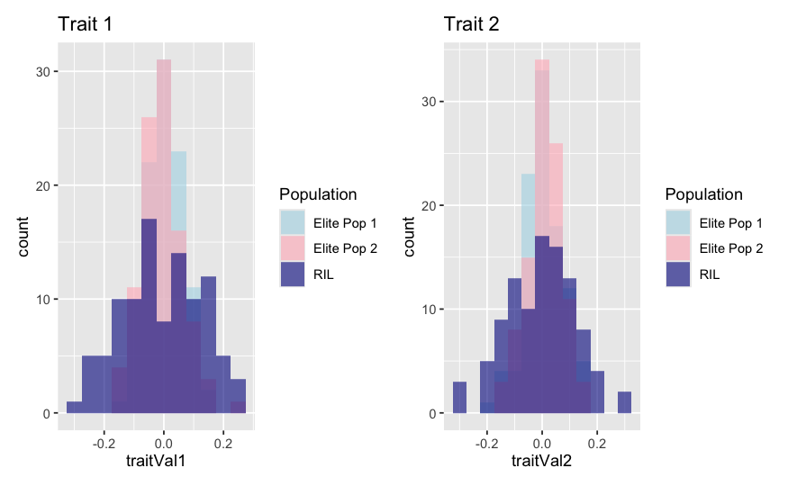

```r
t1 <- ggplot(data=result_df, aes(x=traitVal1, fill=pop)) +
  geom_histogram(position='identity', binwidth = 0.05, alpha=0.6) +
  scale_fill_manual(name = "Population",
                      values = c("RIL" = "darkblue",
                                "Elite Pop 1" = "lightblue",
                                "Elite Pop 2" = "lightpink")) +
  labs(title="Trait 1")

t2 <- ggplot(data=result_df, aes(x=traitVal2, fill=pop)) +
  geom_histogram(position='identity', binwidth = 0.05, alpha=0.6) +
  scale_fill_manual(name = "Population",
                    values = c("RIL" = "darkblue",
                               "Elite Pop 1" = "lightblue",
                               "Elite Pop 2" = "lightpink")) +
  labs(title="Trait 2")

(t1|t2)

save_dir <- file.path(output_dir, "EliteVSRIL")
if (!dir.exists(save_dir)) dir.create(save_dir)
save_dir <- file.path(save_dir, format(Sys.time(), "%F_%H_%M_%S"))
if (!dir.exists(save_dir)) dir.create(save_dir)

fname <- file.path(save_dir, "EliteVSRil.pdf")
ggplot2::ggsave(filename = fname,
                device = "pdf")
```

Pull out individuals from each population and cross them Create RILs

```r
getSigQtl <- function(RIL, parentA, parentB, savePlot=FALSE) {
  cross <- getCross(RIL, parentA, parentB, "riself")
  cross <- drop.nullmarkers(cross)
  phes <- phenames(cross)[1:2]
  cross <- calc.genoprob(cross, step=n.step, error.prob=n.errorProb)
  out.hk <- scanone(cross, pheno.col=phes, method=n.mappingMethod)
  operm.hk <- scanone(cross, pheno.col=phes, method=n.mappingMethod, n.perm=1000)
  sigQtl <- pullSigQTL(cross,
                       pheno.col=phes,
                       s1.output=out.hk,
                       perm.output=operm.hk,
                       returnQTLModel=FALSE,
                       alpha=0.05,
                       controlAcrossCol=TRUE)
  if (savePlot) {
    save_dir <- file.path(output_dir, "QtlMapping")
    if (!dir.exists(save_dir)) dir.create(save_dir)
    save_dir <- file.path(save_dir, format(Sys.time(), "%F_%H_%M_%S"))
    if (!dir.exists(save_dir)) dir.create(save_dir)
    fname <- file.path(save_dir, "linkagemap.pdf")

    pdf(fname)
    cols <- c("blue", "red")
    plot(out.hk, type="n", ylim=c(0,max(as.matrix(out.hk[,-c(1:2)]))), ylab= "LOD Score")
    for (i in 1:length(phes)) plot(out.hk, add=T, lodcolumn = i, col = cols[i])
    abline(h=summary(operm.hk[1,1]), col="blue", lty = "dotted", lwd=2)
    abline(h=summary(operm.hk[1,2]), col="red", lty = "dotted", lwd=2)
    dev.off()

    geno = rbind(pullQtlGeno(RIL), pullQtlGeno(parentA), pullQtlGeno(parentB))
    PCA  = dudi.pca(df = geno, center = T, scale = F, scannf = F, nf = 5)
    (VAF = 100 * PCA$eig[1:5] / sum(PCA$eig)) # variance explained
    df.PCA = data.frame(
      "Pop" = c(rep("RIL", RIL@nInd), "Parent A", "Parent B"),
      "PC1" = PCA$l1$RS1,
      "PC2" = PCA$l1$RS2)
    ggplot(df.PCA, aes(x = PC1, y = PC2)) +
      geom_point(aes(colour = factor(Pop))) +
      ggtitle("Population structure") +
      xlab(paste("Pcomp1: ", round(VAF[1], 2), "%", sep = "")) +
      ylab(paste("Pcomp2: ", round(VAF[2], 2), "%", sep = ""))

    fname <- file.path(save_dir, "PCA.pdf")
    ggplot2::ggsave(filename = fname,
                    device = "pdf")
  }
  return (nrow(sigQtl))
}
#source("CreateFounderPop.R")
popA_popB <- createIndependentPops()
popA <- popA_popB[1:n.subPopSize]
popB <- popA_popB[(n.subPopSize+1):(n.subPopSize*2)]
res <- createRIL(interPop=TRUE)
RIL <- res[1:(length(res)-2)]
parentA <- res[length(res)-1]
parentB <- res[length(res)]

getSigQtl(RIL, parentA, parentB, savePlot=TRUE)
```

QTL Simulation

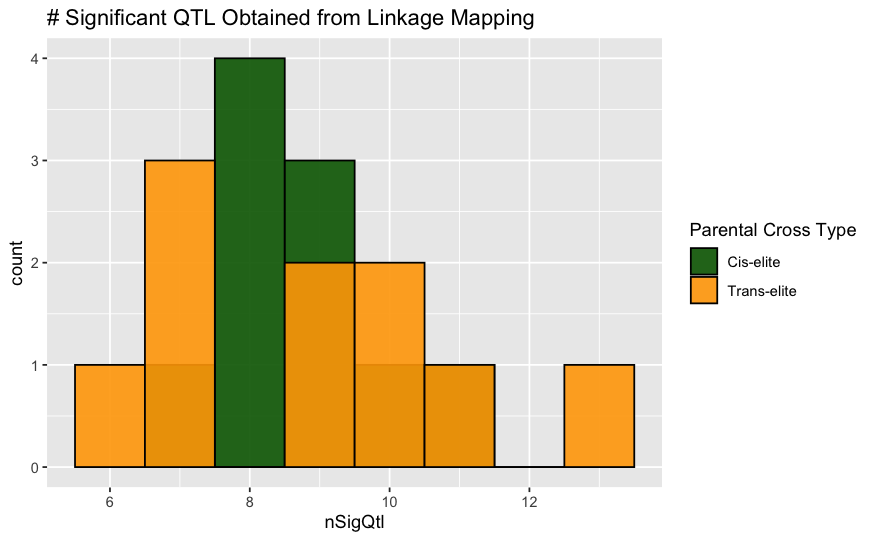

```r
ggplot(data=res.df, aes(x=nSigQtl, fill=type)) +
  geom_histogram(position='identity', binwidth = 1, col='black', alpha=0.9) +
  scale_fill_manual(name = "Parental Cross Type",
                    values = c("Trans-elite" = "orange",
                               "Cis-elite" = "darkgreen")) +
  labs(title="# Significant QTL Obtained from Linkage Mapping", xaxis="# QTL")

save_dir <- file.path(output_dir, "AverageNumSignificantQtl")
if (!dir.exists(save_dir)) dir.create(save_dir)
save_dir <- file.path(save_dir, format(Sys.time(), "%F_%H_%M_%S"))
if (!dir.exists(save_dir)) dir.create(save_dir)
fname <- file.path(save_dir, "significantqtl.pdf")
ggplot2::ggsave(filename = fname,
                device = "pdf")
```

GWAS

```r
snpGeno = pullSnpGeno(gwasPop)

geno = data.frame(
  snp = colnames(snpGeno),
  chr = c(ncol(snpGeno)),
  pos = rep(1:n.markers, 10),
  t(snpGeno - 1)
)
pheno = data.frame(id = 1:F2@nInd,
                    pheno  = F2@pheno)
colnames(geno)[-c(1:3)] = 1:F2@nInd
trait <- 2
model1 = GWAS(pheno[,c(1,trait+1)], geno, plot = T)
model2 = GWAS(pheno[,c(1,trait+1)], geno, n.PC = 3, plot = T)

model1$Trait1 = 10 ^ (-model1$pheno.Trait1)
model2$Trait1 = 10 ^ (-model2$pheno.Trait1)

model1$Trait2 = 10 ^ (-model1$pheno.Trait2)
model2$Trait2 = 10 ^ (-model2$pheno.Trait2)

qtl1 = as.vector(getQtlMap(trait = 1)$id)
qtl2 = as.vector(getQtlMap(trait = 2)$id)
par(mfrow = c(2, 1))
manhattan(model1, chr = "chr", bp = "pos", p = "pheno.Trait2", snp = "snp", highlight = qtl2,
  main = "Marker", ylim = c(0,10))
manhattan(model2, chr = "chr", bp = "pos", p = "pheno.Trait2", snp = "snp", highlight = qtl2,
  main = "Marker + principal components", ylim = c(0,10))
# Check QQ-plot
par(mfrow = c(2, 1))
qq(model1$Trait1, main = "Marker")
qq(model2$Trait1, main = "Marker + principal components")
```

QTL stuff not being used

```r
#plot(cross)
#nmar(cross)
#plot.map(pull.map(cross),est.map(cross))
#summary(operm.hk, alpha=0.05, pvalues=TRUE)


#mar <- find.marker(cross, chr=10, pos=63.3)
#plotPXG(cross, marker=mar)
#effectplot(cross, mname1=mar)
#out.cim <- cim(cross, n.marcovar=3)
#plot(out.cim)

data("multitrait")
data(multitrait)
data(map10)
plot(map10)
simcross <- sim.cross(map10, type="f2", n.ind=100, missing.prob=0.02)
plot.map(pull.map(simcross),est.map(simcross))
geno.table(simcross, chr=1)

cross <- est.rf(cross)
plotRF(cross)
plotMissing(cross)
geno.table(cross, chr=1)
cg <- comparegeno(cross)
hist(cg[lower.tri(cg)], breaks=seq(0, 1, len=101), xlab="No. matching genotypes")
print(dup <- findDupMarkers(cross, exact.only=FALSE))
rug(cg[lower.tri(cg)])
gt <- geno.table(cross)
gt[gt$P.value < 0.05/totmar(cross),]

g <- pull.geno(cross)
gfreq <- apply(g, 1, function(a) table(factor(a, levels=1:3)))
gfreq <- t(t(gfreq) / colSums(gfreq))
par(mfrow=c(1,3), las=1)
for(i in 1:3) {
  plot(gfreq[i,], ylab="Genotype frequency", main=c("AA", "AB", "BB")[i], ylim=c(0,1))
}

newMap <- est.map(cross, error.prob=0.01)
plotMap(cross, newMap)
```